[figure not shown]

# IoT-Cloud Batch Processing-on Step-by-Step Guide

In this hands-on we are going to explore batch processing using Pyspark and we are going to use the AWS Sage maker platform for this. The following are the steps - • We will create a notebook within AWS Sagemaker • We will use pyspark to create aggregate data, partitions, and moving averages of the collected data.

## AWS Sagemaker : Instance creation

Search for Sagemaker service on AWS and choose t. Click on `notebook` option available in the left pa e. On the next page click on `Create notebook instance`.

[figure not shown]

Enter the appropriate name for the notebook instance. Under the IAM role choose `create new role`.After creating the new role, Choose the newly created IAM role from the drop down option. Once done click on Create notebook instance.

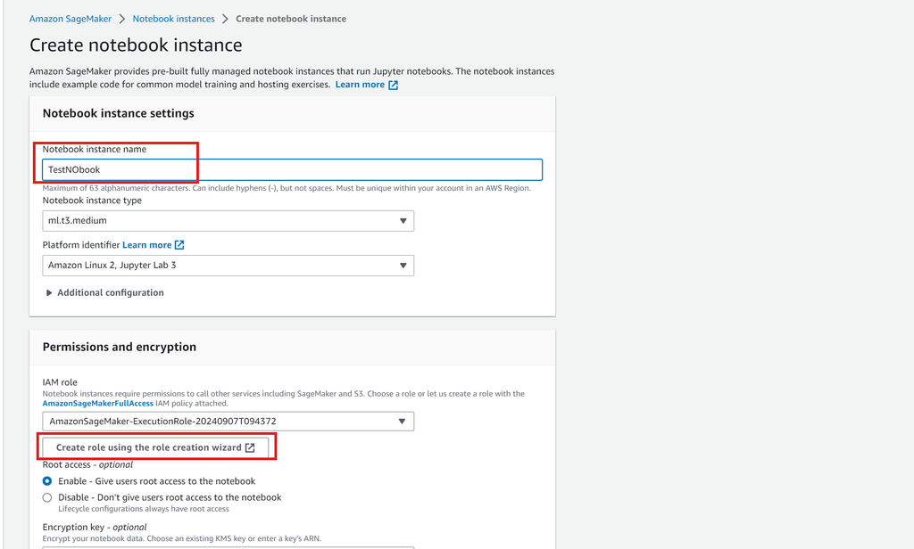

It will take 2-3 minutes to up the server and status will become `InService`.

[figure not shown]

Click on open jupyter option available for that particular instance. This will open a new window where we will be creating and uploading the data for our task. Click on New to create the notebook. After clicking on New, choose conda_python3.

[figure not shown]

After clicking it a new window will open with the chosen kernel.

[figure not shown]

## HeartRate Data example : Problem Statement

In this problem statement we are going to simulate data of heart rate readings for a week.

Created data will have per minute information of heart rate readings. Data will be then used to create the aggregated information as mentioned below:

- Create aggregated data by combining per minute data into 15 minute interval data.
- Calculate the moving average of heart rate reading for every 15 minute.

# Sample data creation

In this section we are going to use a simple script which can be used to create the csv files for the heartrate readings.

This script will create one csv file which will have per minute heart arte readngs for one week.

```python
import datetime
import csv
import random

def datetime_range(start, end, delta):
    current = start
    with open('HeartRateData01.csv', 'w', newline='') as file:
        writer = csv.writer(file)
        count = 1
        writer.writerow(["SerialNo", "CurrentTime", "CurrentTS", "SubjectId", "HeartRate"])
        while current < end:
            value = int(random.normalvariate(85,12))
            yield current
            currentTS = current.timestamp()
            writer.writerow([count, current, currentTS, "S1098", value])
            current += delta
            count += 1

dts = [dt.strftime('%Y-%m-%d T%H:%M:%S Z') for dt in
       datetime_range(datetime.datetime(2019, 9, 1, 0, 0), datetime.datetime(2019, 9, 8, 0, 0),
       datetime.timedelta(seconds=60))]
```

This cell is generating the `HeartRate` data for our task. Create data from this script will be inserted in a csv file named as `HeartRateData01.csv`. Once this script is successfully executed `HeartRateData01.csv` will be generated which you can see in Jupyter Notebook running on AWS sagemaker.

[figure not shown]

[figure not shown]